# HW_Assignment_4_Ahmed_Hassan

Ahmed Hassan

2024-09-29

Creating a csv file out of the data

```r
airlines_data <- data.frame(
  Airline = c("ALASKA", "ALASKA", "AM WEST", "AM WEST"),
  Status = c("on time", "delayed", "on time", "delayed"),
  Los_Angeles = c(497, 62, 694, 117),
  Phoenix = c(221, 12, 4840, 415),
  San_Diego = c(212, 20, 383, 65),
  San_Francisco = c(503, 102, 320, 129),
  Seattle = c(1841, 305, 201, 61)
)

print(airlines_data)
```

```
##   Airline  Status Los_Angeles Phoenix San_Diego San_Francisco Seattle
## 1  ALASKA on time         497     221       212           503    1841
## 2  ALASKA delayed          62      12        20           102     305
## 3 AM WEST on time         694    4840       383           320     201
## 4 AM WEST delayed         117     415        65           129      61
```

```r
write.csv(airlines_data, "data/airline_delays.csv", row.names = FALSE)
```

Reading back the data from my csv

```r
library(tidyverse)
airlines_data <- read.csv("data/airline_delays.csv")
print(airlines_data)
```

```
##   Airline  Status Los_Angeles Phoenix San_Diego San_Francisco Seattle
## 1  ALASKA on time         497     221       212           503    1841
## 2  ALASKA delayed          62      12        20           102     305
## 3 AM WEST on time         694    4840       383           320     201
## 4 AM WEST delayed         117     415        65           129      61
```

Doing Transformations to the Data. Ex: Adding new columns such as totals

```r
airlines_data$sums <- rowSums(airlines_data[, 3:7])
#print(airlines_data)

#creating a new df for now to test to see if this would be a better approach than having the total_flights row in the original df
total_flights_df <- airlines_data %>%
  group_by(Airline) %>%
  summarise(Total_Flights = sum(sums))

print(total_flights_df)
```

```
## # A tibble: 2 × 2
##   Airline Total_Flights
##   <chr>           <dbl>
## 1 ALASKA           3775
## 2 AM WEST          7225
```

```r
airlines_data <- airlines_data %>%
  group_by(Airline) %>%
  mutate(Total_Flights = sum(sums))

print(airlines_data)
```

```
## # A tibble: 4 × 9
## # Groups:   Airline [2]
##   Airline Status  Los_Angeles Phoenix San_Diego San_Francisco Seattle  sums
##   <chr>   <chr>         <int>   <int>     <int>         <int>   <int> <dbl>
## 1 ALASKA  on time         497     221       212           503    1841  3274
## 2 ALASKA  delayed          62      12        20           102     305   501
## 3 AM WEST on time         694    4840       383           320     201  6438
## 4 AM WEST delayed         117     415        65           129      61   787
## # ℹ 1 more variable: Total_Flights <dbl>
```

```r
airlines_data <- airlines_data %>%
  mutate(Percentage = (sums / Total_Flights) * 100)

print(airlines_data)
```

```
## # A tibble: 4 × 10
## # Groups:   Airline [2]
##   Airline Status  Los_Angeles Phoenix San_Diego San_Francisco Seattle  sums
##   <chr>   <chr>         <int>   <int>     <int>         <int>   <int> <dbl>
## 1 ALASKA  on time         497     221       212           503    1841  3274
## 2 ALASKA  delayed          62      12        20           102     305   501
## 3 AM WEST on time         694    4840       383           320     201  6438
## 4 AM WEST delayed         117     415        65           129      61   787
## # ℹ 2 more variables: Total_Flights <dbl>, Percentage <dbl>
```

```r
percentages_of_total_per_city_df <- airlines_data %>%
  group_by(Airline, Status) %>%
  summarise(
    Los_Angeles = (Los_Angeles/ sums) * 100,
    Phoenix = (Phoenix / sums) * 100,
    San_Diego = (San_Diego / sums) * 100,
    San_Francisco = (San_Francisco / sums) * 100,
    Seattle = (Seattle / sums) * 100
  ) %>%
  ungroup()
#using this line of code to verify that we get 100%. My small test case to show everything is going good so far.
percentages_of_total_per_city_df$sums <- rowSums(percentages_of_total_per_city_df[, 3:7])
print(percentages_of_total_per_city_df)
```

```
## # A tibble: 4 × 8
##   Airline Status  Los_Angeles Phoenix San_Diego San_Francisco Seattle  sums
##   <chr>   <chr>         <dbl>   <dbl>     <dbl>         <dbl>   <dbl> <dbl>
## 1 ALASKA  delayed        12.4    2.40      3.99         20.4    60.9    100
## 2 ALASKA  on time        15.2    6.75      6.48         15.4    56.2    100
## 3 AM WEST delayed        14.9   52.7       8.26         16.4     7.75   100
## 4 AM WEST on time        10.8   75.2       5.95          4.97    3.12   100
```

```r
#print(airlines_data)
```

pie chart for on time

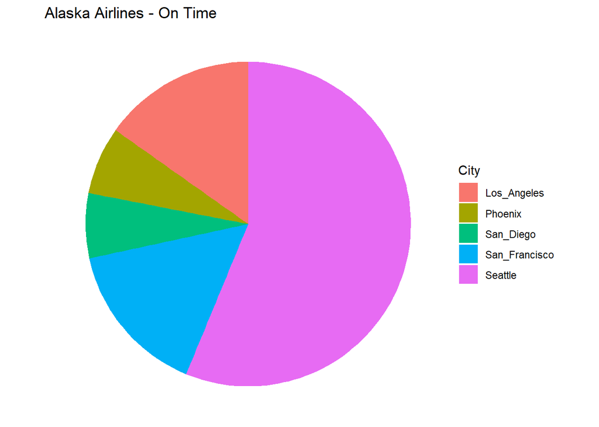

```r
library(ggplot2)
library(tidyr)
library(dplyr)

alaska_on_time <- percentages_of_total_per_city_df %>%
  filter(Airline == "ALASKA" & Status == "on time") %>%
  select(Los_Angeles, Phoenix, San_Diego, San_Francisco, Seattle)

amwest_on_time <- percentages_of_total_per_city_df %>%
  filter(Airline == "AM WEST" & Status == "on time") %>%
  select(Los_Angeles, Phoenix, San_Diego, San_Francisco, Seattle)

plot_pie_chart <- function(data, title) {
  city_names <- c("Los_Angeles", "Phoenix", "San_Diego", "San_Francisco", "Seattle")
  flight_values <- as.numeric(data[1, ])

  pie_data <- data.frame(
    City = city_names,
    Percentage = flight_values
  )

  ggplot(pie_data, aes(x = "", y = Percentage, fill = City)) +
    geom_bar(width = 1, stat = "identity") +
    coord_polar("y") +
    labs(title = title, y = "Percentage", x = NULL) +
    theme_void() +
    theme(legend.position = "right")
}

plot_pie_chart(alaska_on_time, "Alaska Airlines - On Time")
```

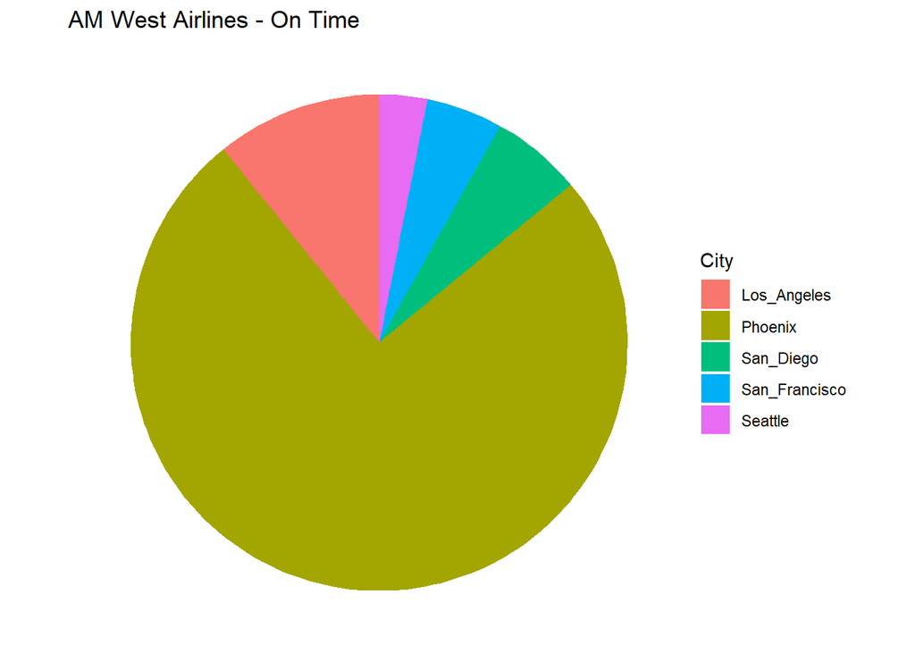

```r
plot_pie_chart(amwest_on_time, "AM West Airlines - On Time")
```

pie chart for delay

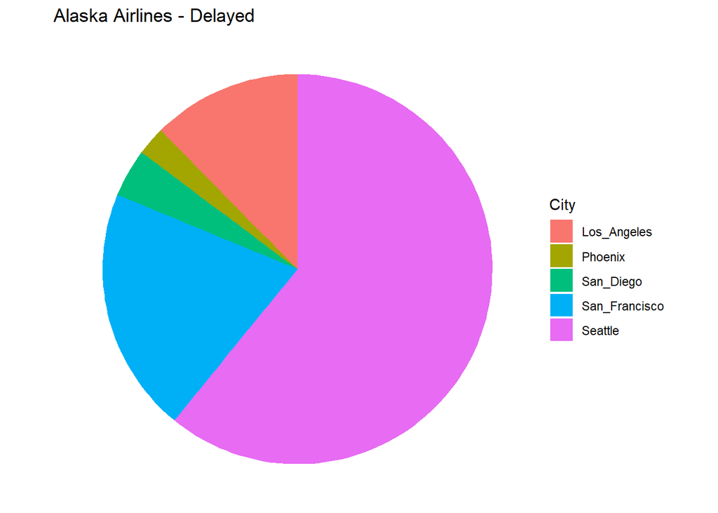

```r
alaska_delayed <- percentages_of_total_per_city_df %>%
  filter(Airline == "ALASKA" & Status == "delayed") %>%
  select(Los_Angeles, Phoenix, San_Diego, San_Francisco, Seattle)

amwest_delayed <- percentages_of_total_per_city_df %>%
  filter(Airline == "AM WEST" & Status == "delayed") %>%
  select(Los_Angeles, Phoenix, San_Diego, San_Francisco, Seattle)

plot_pie_chart <- function(data, title) {
  city_names <- c("Los_Angeles", "Phoenix", "San_Diego", "San_Francisco", "Seattle")
  flight_values <- as.numeric(data[1, ])

  pie_data <- data.frame(
    City = city_names,
    Percentage = flight_values
  )

  ggplot(pie_data, aes(x = "", y = Percentage, fill = City)) +
    geom_bar(width = 1, stat = "identity") +
    coord_polar("y") +
    labs(title = title, y = "Percentage", x = NULL) +
    theme_void() +
    theme(legend.position = "right")
}

plot_pie_chart(alaska_delayed, "Alaska Airlines - Delayed")
```

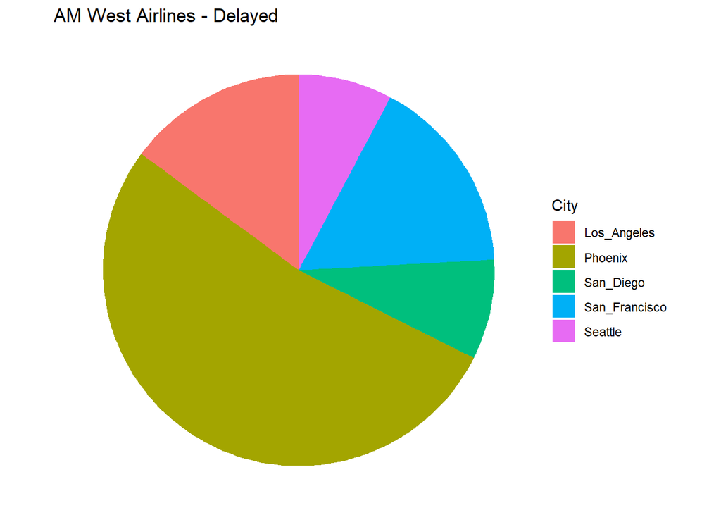

```r
plot_pie_chart(amwest_delayed, "AM West Airlines - Delayed")
```

Bar chart for alaska airlines

```r
alaska_data <- airlines_data %>%
  filter(Airline == "ALASKA") %>%
  select(Status, Los_Angeles, Phoenix, San_Diego, San_Francisco, Seattle)
```

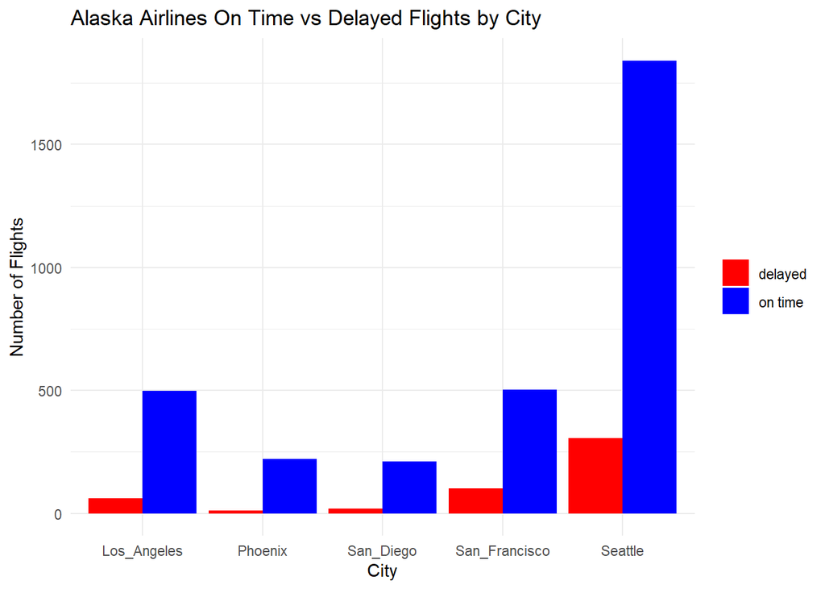

```r
long_alaska_data <- alaska_data %>%
  pivot_longer(cols = Los_Angeles:Seattle,
               names_to = "City",
               values_to = "Flights")

# Create the bar chart
ggplot(long_alaska_data, aes(x = City, y = Flights, fill = Status)) +
  geom_bar(stat = "identity", position = "dodge") +
  labs(title = "Alaska Airlines On Time vs Delayed Flights by City",
       x = "City",
       y = "Number of Flights") +
  theme_minimal() +
  scale_fill_manual(values = c("on time" = "blue", "delayed" = "red")) +
  theme(legend.title = element_blank())
```

Alaksa airlines stacked

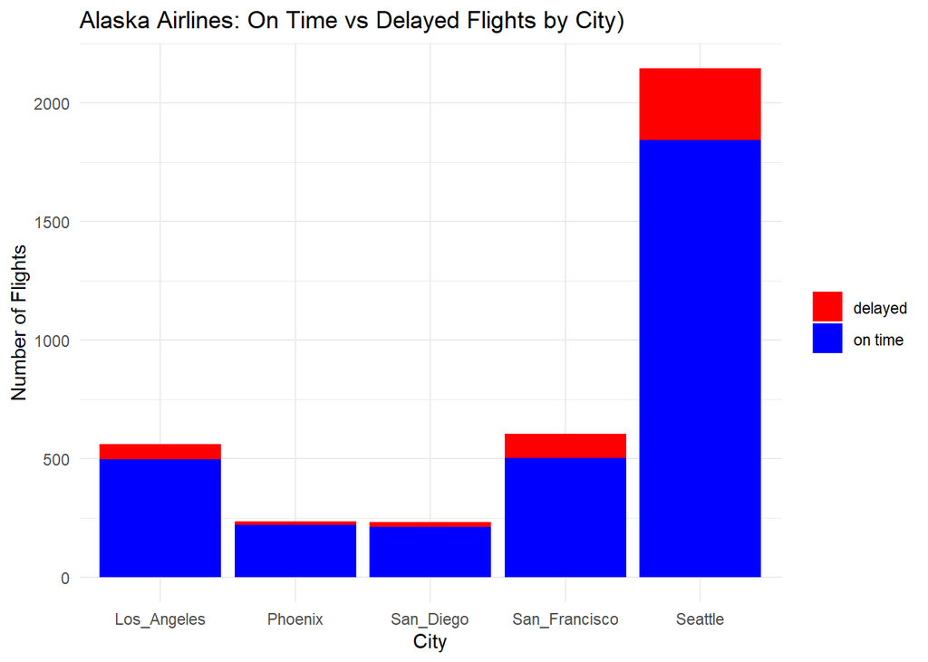

```r
ggplot(long_alaska_data, aes(x = City, y = Flights, fill = Status)) +
  geom_bar(stat = "identity", position = "stack") +
  labs(title = "Alaska Airlines: On Time vs Delayed Flights by City)",
       x = "City",
       y = "Number of Flights") +
  theme_minimal() +
  scale_fill_manual(values = c("on time" = "blue", "delayed" = "red")) +
  theme(legend.title = element_blank())
```

I Would rather used the stacked bar chart than side by side

Am west bar chart stacked

```r
am_west_data <- airlines_data %>%
  filter(Airline == "AM WEST") %>%
  select(Status, Los_Angeles, Phoenix, San_Diego, San_Francisco, Seattle)
```

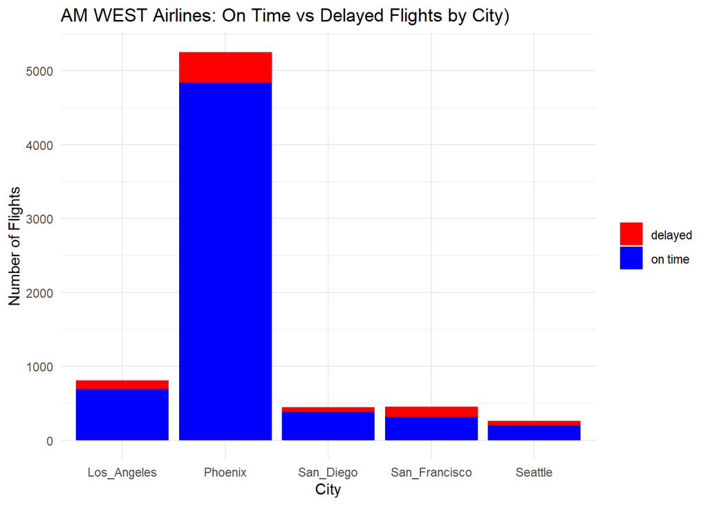

```r
long_am_west_data <- am_west_data %>%
  pivot_longer(cols = Los_Angeles:Seattle,
               names_to = "City",
               values_to = "Flights")


ggplot(long_am_west_data, aes(x = City, y = Flights, fill = Status)) +
  geom_bar(stat = "identity", position = "stack") +
  labs(title = "AM WEST Airlines: On Time vs Delayed Flights by City)",
       x = "City",
       y = "Number of Flights") +
  theme_minimal() +
  scale_fill_manual(values = c("on time" = "blue", "delayed" = "red")) +
  theme(legend.title = element_blank())
```

After making my bar chart and pie charts and taking percentages, I am ready to talk about the flight delays for both airlines. When I created the pie chart, at first it was easy for me to say to avoid Alaska Airlines and AM West Airlines going to Seattle but definitely take both when going to Phoenix. These however are just showing percentages delays. The Bar chart are a better use of the data to see the total comparison for both the delays and the ones that arrived on times.

Lets Start with Alaska Airlines using the stacked bar chart. We see the majority of flights that are delayed are from settle. Now Lets look at Am West Airlines and we see that phoenix has the highest delays. But both those cities also have th most flights going into those cities by an overwhelmingly majority for both airlines.

Now lets talk about the data we see for alaska airlines. We face the issue as before as we have a large amount of flights going into seattle compared to the other cities. This is why we would see a larger amount of flight delays going into seattle due to there being a large amount of trips landing in seattle. We do however still see that the majority of flights landing in seattle are on time, therefore consumer confidence should remain high as the flights land in seattle. The same thing can be said about the other cities as the majority of flights landing in all the other cities are arriving on time. The flight delays are proportionally low compared to arrival on times. There should be high confidence in taking alaska airlines to arriving into any of the following cities taking alaska airlines.